*Created by Petteri Nevavuori <petteri.nevavuori@gmail.com>*

**CHIO & FREEMAN: MACHINE LEARNING & SECURITY (2018)**  
*Otsikot kirjan mukaan, muutoin suomeksi.*

# Classifying and Clustering

Tässä luvussa käydään läpi tietoturvasovellusten käyttökelpoisimpia koneoppimismenetelmiä, niiden perusteista aina käyttökelpoisen koneoppimistyökalupakin rakentamiseen. Luvussa pysyttäydytään menetelmien toiminnan ymmärtämisen tasossa menemättä nyansseihin.

## Machine Learning: Problems and Approaches

Koneoppimismenetelmät ovat pohjimmiltaan algoritmeja ja historiallista dataa hyödyntäviä prosesseja tulevaisuuden tapahtumien luokitteluun (*classification*) tai arvojen ennustamiseen (*regression*). Luokittelu voi olla *binääristä* joko-tai-luokittelua tai sitten luokittelua yhdeksi tai useaksi monesta mahdollisesta luokasta (*multiclass classification*).

Tietoturvaan liittyvät ongelmat liittyvät suuressa määrin jatkuvaan havainnointiin, jossa kukin uusi tilanne on kyettävä luokittelemaan joko turvalliseksi tai uhaksi. Näitä tilanteita ovat esimerkiksi jokainen uusi tiedosto, sähköposti, kirjautumisyritys ja palvelimelle tullut pyyntö. Ihmisvoimin käsitellen tehtävä osoittautuu piankin mahdottomaksi, mutta käyttämällä dataa eli vaikkapa kirjautumistietojen, tiedostojen, yhteydenottopyyntöjen jne. lokitiedostoja (*logs*) yhdessä datasta piirteitä oppivien mallien kanssa tehtävä helpottuu ja voidaan myös automatisoida.

Arvojen ennustaminen eli regressio tulee kyseeseen, kun halutaan saada luotettava arvio vaikkapa johonkin työntekijään kohdistuneista kalasteluyrityksistä (*phishing*) kuukautta kohden. Tällöin logien sijasta käytetään muita muuttujia, kuten henkilön asema työpaikalla, käyttöoikeudet, viran pituus yms. Mikäli taas arvoja ennustetaan datasta, jossa on mukana myös ajan ulottuvuus eli peräkkäisiä havaintoja joiden oletetaan vaikuttavan ennustettavaan tulokseen, ollaan tekemisissä aikasarja-analyysin (*time series analysis*) kanssa. Tietoturvakonteksissa aikasarja-analyysiä voidaan käyttää ennustamaan normaalia kirjautumisten määrää vaikkapa jostain toimipisteestä, mitä sitten voidaan verrata ja tarvittaessa huomata mahdollinen kirjautumisten määrän poikkeava kasvu. Esimerkeistä viimeisin on hyvä esimerkki samalla myös poikkeamien havaitsemisesta (*anomaly detection*).

Poikkeamia voidaan havaita myös ryhmittelymenetelmillä (*clustering*). Tällöin menetelmälle syötetty data ryhmitellään eli *klusteroidaan* havaintojen samankaltaisuuden perusteella suuremmiksi pääryhmiksi. Ryhmittelymenetelmälle voidaan opettaa esimerkiksi turvallisia tapahtumia. Sen kohdatessa uhaksi tulkittavan havainnon jää kyseinen havainto opittujen ryhmien ulkopuolelle. Ryhmittelyllä voidaan saada ymmärrystä myös vaikkapa sivustolle lähetetyistä pyynnöistä - mitkä pyynnöistä ovat todennäköisesti bottiverkon (*botnet*) lähettämiä pyyntöjä, mitkä taas virallisia.

Koneoppiminen jaetaan perinteisesti myös ohjattuihin (*supervised*) ja ohjaamattomiin (*unsupervised*) menetelmiin. Luokittelu- ja regressiomenetelmät ovat perinteisesti ohjattuja, jolloin niitä koulutettaessa menetelmille syötetään havaintotiedon lisäksi myös oikea vastaus - luokka tai lukuarvo. Käytännön esimerkki ohjatuista menetelmistä on edellisen luvun roskapostien tunnistaminen, jossa luokka oli ennalta jo tiedossa. Ryhmittelymenetelmät pohjaavaat lähes aina dataan itseensä etsien ja ryhmitellen dataa sen sisäisten ominaisuuksien perusteella. Tämä on ohjaamatonta oppimista, eli menetelmän annetaan itse määrittää datalle ominaiset ryhmät ja niiden ominaisuudet.

## Machine Learning in Practice: A Worked Example

Tässä esimerkissä käytetään ostotapahtumista (*transaction*) muodostettua datasettiä, joka löytyy [kirjan GitHubista](https://github.com/oreilly-mlsec/book-resources/blob/master/chapter2/datasets/payment_fraud.csv). Datasetissä on viisi piirrettä talletettuna kustakin tapahtumasta sekä tieto siitä, oliko ostotapahtuma petos (*fraud*) vai ei. Tieto siitä, onko jokin ostotapahtuma ollut petos vai ei, on saatu keräämällä tietoa tapahtumiin liittyvistä mitätöintipyynnöistä - mikäli käyttäjä on epäillyt maksuvälineensä väärinkäyttöä, hän on pyytänyt tehdyn ostoksen mitätöinti ja rahojen palautusta. Pyynnöt eivät kuitenkaan ole reaaliaikaisesti käytettävissä, sillä niitä tehdään jopa kuukausia tapahtuman jälkeen. Tällöin myös ostetut tavarat on ehditty jo lähettää, eikä niitä juuri saada enää takaisin. Siksi onkin merkittävää kyetä ennustamaan, mikäli jokin ostotapahtuma ilmentää petollisia piirteitä ja estää mahdollinen liiketoimintahäviö jo ennen tavaran lähetystä.

Ensin ladataan tiedot käyttöön ja tarkastellaan muutamaa ensimmäistä riviä.

```python
import os
import pandas as pd

ROOT_DIR = os.path.dirname(os.getcwd())
DATASET_PATH = os.path.join(ROOT_DIR, 'datasets', 'payment_fraud.csv')

dataset = pd.read_csv(DATASET_PATH)
dataset.head()
```

|  | accountAgeDays | numItems | localTime | paymentMethod | paymentMethodAgeDays | label |
| --- | --- | --- | --- | --- | --- | --- |
| 0 | 29 | 1 | 4.745402 | paypal | 28.204861 | 0 |
| 1 | 725 | 1 | 4.742303 | storecredit | 0.000000 | 0 |
| 2 | 845 | 1 | 4.921318 | creditcard | 0.000000 | 0 |
| 3 | 503 | 1 | 4.886641 | creditcard | 0.000000 | 0 |
| 4 | 2000 | 1 | 5.040929 | creditcard | 0.000000 | 0 |

Datasetin muuttujat ovat yhtä lukuunottamatta sellaisenaan käytettävässä muodossa. Maksutapaa ilmaiseva `paymentMethod` sisältää kuitenkin kategorisia arvoja, joiden kanssa on toimittava erityistä huomiota kiinnittäen. Koska koneoppimismenetelmät toimivat luvuilla, on tekstimuotoiset tiedot ensinnäkin muutettava luvuiksi. Pelkkä `paypal => 1, storecredit => 2, ...` muunnos ei kuitenkaan ole kelvollinen, sillä muuttujilla ei ole lineaarista suhdetta toisiinsa - Paypal ei ole maksuvälineenä suurempi, parempi tai huonompi, kuin käteinen.

Kategorisia muuttujia sisältävä sarake tavataan usein hajoittaa useaksi sarakkeeksi siten, että jokainen hajoitettu sarake vastaa yhtä alkuperäisen sarakkeen uniikkia arvoa. Toisin sanoen sarake

| Sankarit |
| --- |
| Nalle Puh |
| Hämis |
| Mustanaamio |

hajoitettaisiin useaksi sarakkeeksi seuraavasti:

| Sankarit: Nalle Puh | Sankarit: Hämis | Sankarit: Mustanaamio |
| --- | --- | --- |
| 1 | 0 | 0 |
| 0 | 1 | 0 |
| 0 | 0 | 1 |

Tämä tunnetaan valemuuttujien (*dummy variables*) muodostamisena sekä [*one-hottauksena*](https://en.wikipedia.org/wiki/One-hot). Valemuuttujien muodostamisen lisäksi, vaikka kirjassa tätä ei toistaiseksi käsitellä, on myös tavallista varmistua datasetin muuttujien *yksiselitteisyydestä*. Esimerkkimme taulukossa meillä on kolme arvoa ja loogisesti seuraten sen hajoitetussa versiossa kolme saraketta. Hajoitettu taulukko sisältää kuitenkin enemmän informaatiota, kuin mitä tarvitaan sankarin määrittämiseen yksiselitteisesti. Jos sankari on Nalle Puh tai Hämis, arvo on yksiselitteinen. Jos sankari ei ole kumpikään näistä, se on edelleen yksiselitteinen, sillä ainoa jäljelle jäävä vaihtoehto on Mustanaamio. Tieto Mustanaamiosta on siis ylimääräinen ja se itseasiassa aiheuttaa mallin [piirteiden selityskykyä alentavan ongelman](https://en.wikipedia.org/wiki/Multicollinearity), vaikkakaan suorituskyky tarkkuuden näkökulmasta ei kärsisikään.

Siispä seuraavaksi korvataan `paymentMethod`-sarake sen arvoista muodostetuilla valesarakkeilla jättäen yksi sarakkeista pois.

```python
print(
    f'Unique paymentMethod categories: {list(dataset.paymentMethod.unique())}')
dataset = pd.get_dummies(dataset, prefix='paymentMethod', columns=[
                         'paymentMethod'], drop_first=True)
dataset.head()
```

```
Unique paymentMethod categories: ['paypal', 'storecredit', 'creditcard']
```

|  | accountAgeDays | numItems | localTime | paymentMethodAgeDays | label | paymentMethod_paypal | paymentMethod_storecredit |
| --- | --- | --- | --- | --- | --- | --- | --- |
| 0 | 29 | 1 | 4.745402 | 28.204861 | 0 | 1 | 0 |
| 1 | 725 | 1 | 4.742303 | 0.000000 | 0 | 0 | 1 |
| 2 | 845 | 1 | 4.921318 | 0.000000 | 0 | 0 | 0 |
| 3 | 503 | 1 | 4.886641 | 0.000000 | 0 | 0 | 0 |
| 4 | 2000 | 1 | 5.040929 | 0.000000 | 0 | 0 | 0 |

Datan esikäsittely on nyt valmis. Seuraavaksi jatketaan jo opittuun malliin jakaen datasetti koulutus ja testidatoihin. Koulutuksen kohteena (*target*) `y` käytetään datasetin `label` sarakkeen tietoja ja syötedatoina (*input*) `x` kaikkia muita sarakkeita.

```python
from sklearn.model_selection import train_test_split

x, y = dataset.drop('label', axis=1), dataset.label
x_train, x_test, y_train, y_test = train_test_split(x, y, test_size=1/3)
```

Datasettien jakamisen jälkeen valitaan luokitteluun sopiva logistinen regressiomalli (*logistic regression*) lineaaristen mallien perheestä ja koulutetaan eli sovitetaan (*fit*) se dataan. Sen jälkeen muodostetaan ennuste testisetin syötedatoista ja verrataan ennusteita todellisiin tietoihin sekaannusmatriisilla. Sarakkeen `label` arvot on hyvä vielä kerrata: nolla tarkoittaa oikeaa ostotapahtumaa, yksi taas petosta.

```python
from sklearn.linear_model import LogisticRegression
from utils import train_utils

model = LogisticRegression()
model.fit(x_train, y_train)
y_pred = model.predict(x_test)
train_utils.visualize_results_acc_cm(y_test, y_pred)
```

```
Tulokset määrissä:
```

|  | true_0 | true_1 |
| --- | --- | --- |
| model_0 | 12900 | 0 |
| model_1 | 0 | 174 |

```
Tulokset prosenteissa:
```

|  | true_0 | true_1 |
| --- | --- | --- |
| model_0 | 98.669114 | 0.000000 |
| model_1 | 0.000000 | 1.330886 |

```
Mallin tarkkuus (ON+OP): 100.000%
```

Kouluttamamme malli onnistui luokittelemaan ostotapahtumat niiden tekohetkellä sille syötetyn datasetin pohjalta täydellisesti. Huomionarvoista on kuitenkin, että tämä ei tarkoita sitä, että malli olisi täydellinen todellisessa käytössä - sitä pitäis kouluttaa uudelleen ja uudelleen aina uusien havaintojen myötä.

## Training Algorithms to Learn

Ytimessään koneoppimisalgoritmit muodostavat määrämuotoisesta koulutusdatasta mallin. Algoritmit luokitellaan kolmen ominaisuuden perusteella: malliperge (*model family*), kohdefunktio (*objective function*) ja optimointimenetelmä (*optimization procedure*). Seuraavaksi käydään kukin näistä kolmesta piirteestä läpi.

### Model Families

Maksupetosesimerkissä datasetin voidaan ajatella muodostuvan alkuperäisesti viisiulotteisista vektoreista, jossa yksi ulottuvuus vastaa yhtä saraketta eli datan piirrettä. Koneoppimisalgoritmien voidaan ajatella oppivan datan piirreavaruuteen sopivia rajapintoja (*boundary*), joiden avulla malli kykenee luokittelemaan myös sille entuudestaan tuntemattomat havainnot tai ennustamaan niille haluttuja lukuarvoja. Algoritmit oppivat sovittumaan niille annettuun koulutusdataan muuttamalla kullekin algoritmille ominaisia säätöarvoja eli parametreja (*parameters*). Yksinkertaisimmillaan sovittumalla opittu rajapinta on lineaarinen, eli suoraviivainen kahtiajako binäärisiin luokkiin. Todellisuudessa kyseessä on huomattavasti monimutkaisemman pinnan oppiminen (*manifold learning*).

Alla oleva kuva havainnollistaa tätä. Siinä käytety malli (eräs [tukivektorikone](https://fi.wikipedia.org/wiki/Tukivektorikone)) on muodostanut mallin mainoksen vaikutuksesta ostopäätökseen suhteessa kaksiulotteiseen datasettiin (ikä ja tulotaso). Pisteet ovat havaintoja ja tausta on opittu malli. Tarkan "kyllä-ei" rajan piirtäminen ei ole kuitenkaan ainoa lähestymistapa, vaan yhtälailla malli voisi ennustaa ostotodennäköisyyttä välillä `0 ... 1`. Tällöin mallin oppima rajapinnan tarkka raja muuttuisi liukuvaksi todennäköisyydeksi. Eräs tapa toteuttaa tämä on esimerkiksi käyttää mallin oppimaa rajaa 50% todennäköisyytenä ja laskea kunkin pisteen etäisyyttä tähän pisteeseen. Kun etäisyys vielä skaalataan, saadaan etäisyydestä osto- tai hylkäystodennäköisyys.

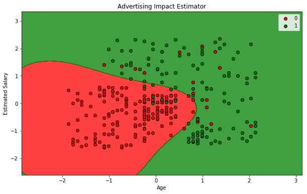

### Loss Functions

Kouluttuakseen algoritmin on saatava tietoa siitä, miten hyvin sen parametreilla saadaan tuotettua oikeita vastauksia vastaavia tuloksia. Näitä mitataan virhefunktioilla (*cost functions*). Perinteisesti paljon käytetty virhefunktio on algoritmin keskimääräisen virheen eli sen ennusteen ja todellisen oikean arvon neliöity erotus (*mean squared error*). Tätä virhefunktiota voidaan käyttää sellaisenaan sekä regressiossa että luokittelussa.

Luokittelun yhteydessä on tavallisempaa käyttää kuitenkin logistista regressiota (*logistic regression*), jossa todennäköisyys lasketaan logistisella funktiolla. Se tunnetaan myös nimellä sigmoidaalifunktio (*sigmoid function*). Sen toiminta havainnollistetaan alla olevassa kuvassa.

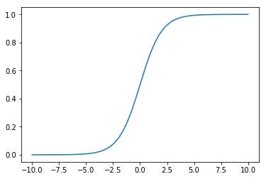

Logistisen regression yhteydessä käytettyä virhfunktiota kutsutaan negatiiviseksi logaritmiseksi todennäköisyydeksi (*negative log likelihood*). Käytännössä erilaisia virhefunktioita löytyy useita, ja onkin hyvä tutustua kulloinkin käytetyn kirjaston tarjontaan ja mahdollisesti kokeilla myös implementoida oma versionsa jostain matemaattisesta virhefunktiosta.

Virhefunktioiden yhteydessä puhutaan myös usein kohdefunktioista (*objective function*). Tässä kohden on kuitenkin hyvä kommentoida kirjaa hieman. Kirjan mukaan nämä tarkoittavat samaa asiaa, mutta kohdefunktio sisältää virhefunktion lisäksi mm. säännöstelyfunktion (*regularization function*), jonka tarkoituksena on kaventaa algoritmin koulutus- ja testivirheen välistä eroa (Goodfellow et al.: Deep Learning, 2016).

### Optimization

Kahdella tähän asti esitellyllä komponentilla saisimme ajettua algoritmimme eli koulutettavan mallimme pisteeseen, jossa pääsisimme selville sen kyvystä suoriutua halutulla datasetillä "hyllystä otettuna". Jotta malli kykenisi tuottamaan mahdollisimman tarkkoja toivottuja tuloksia, on mallin parametreja säädettävä suhteessa sen tuottamaan virheeseen. Tätä kutsutaan koneoppimismenetelmien kohdalla optimoinniksi (*optimization*) ja optimointia varten on oma laaja kirjonsa erilaisia algoritmeja.

Optimointialgoritmin tehtävänä on joko minimimoida tai maksimoida mallin kohdefunktion tuottama arvo. Optimoitavat arvot ovat mallin parametreja, joita muuttamalla tavoitellaan pienintä (tai suurinta) mahdollista kohdefunktion ulostuloa. Optimointialgoritmit voidaan jaotella karkeasti kahteen ryhmään:

- **Ensimmäisen asteen optimointialgoritmit:** Nämä menetelmät käyttävät kohdefunktion arvosta laskettua ensimmäistä derivaattaa (suunta), joka lasketaan kullekin parametrille - tätä kutsutaan myös kaltevuudeksi (*gradient*). Näin päästään käsiksi vapaasti ilmaistuna kunkin mallin parametrin vastuusta virheeseen. Paljon käytetyt jyrkimmän kaltevuuden menetelmät (*gradient descent methods*) ovat ensimmäisen asteen optimointialgoritmeja. Nämä menetelmät ovat laskennallisesti kepeitä, joskin ne voivat jumiutua kohdefunktioon nähden alueelle, josta kohdefunktiota voitaisiin vielä parantaa edelleen - tämä tunnetaan paikalliseen minimiin jumiutumisena (vrt. globaali eli todellinen minimi). Samoin ne voivat joutua tilaan, jossa minimoituminen hidastuu merkittävästi.
- **Toisen asteen optimointialgoritmit:** Vain ensimmäisten derivaattojen sijasta toisen asteen optimointialgoritmit käyttävät myös kohdefunktion toisia derivaattoja (kiihtyvyys) suhteessa mallin parametreihin. Näiden menetelmien etuna on se, että ne ovat paljon vastustuskykyisempiä sekä lokaaleihin minimeihin jumiutumista ja minimoinnin hidastumista vastaan. Toisaalta nämä menetelmät ovat ensimmäisen asteen menetelmiin nähden paljon raskaampia laskennallisesti.

Näistä kahdesta ryhmästä ensimmäisen asteen optimointialgoritmit ovat yleisempiä niiden suhteellisen tehokkuuden vuoksi. Tähän ryhmään kuuluvat mm. seuraavat menetelmät: stokastinen jyrkimmän kaltevuuden menetelmä (*stochastic gradient descent, SGD*) momentilla ja ilman, mukautuva momentin arviointi (*adaptive moment estimation, Adam*), AdaGrad, AdaDelta ja RMSprop. Joka tapauksessa kuhunkin datasettiin sopivan optimointimenetelmän valinta on yrityksen ja erehdyksen kautta tapahtuva valintaprosessi. Siksi on hyvä valita edes kaksi algoritmia, joiden kesken suorittaa vertailua. Voi olla, että toinen menetelmistä onnistuu optimoimaan mallin parametreja huomattavasti paremmin suhteessa kohdefunktioon.

## Supervised Classification Algorithms

Koneoppimisen peruselementtien ripeän läpikäynnin on hyvä siirtyä tarkastelemaan koneoppimisen mallien kirjoa lähemmin. Ensin käydään läpi ohjatun opppimisen luokittelualgoritmeja.

### Logistic Regression

Logistinen regressio mainittiinkin jo aiemmin, joskin varaa laajentamiselle jäi. Se hyvin tehokas eli nopea kouluttaa ja paljonkin käytetty on algoritmi, joka ottaa vastaan lukuja sisältäviä vektoreita. Se pyrkii ennustamaan logaritmista todennäköisyyttä (*log odds, log probability*) kullekin havainnolle tarjoten myös tietoa kunkin syötedatan piirteen merkityksellisyydestä suhteessa muodostettavaan ennusteeseen. Logaritmisella todennäköisyydellä tarkoitetaan sitä, että mikäli jollain tapahtumalla on $p$ prosentin mahdollisuus toteutua, sen tapahtumisen todennäköisyys on $p/(1-p)$ ja logaritminen todennäköisyys kyseiselle tapahtumalle on $log(p/(1-p))$.

Logistinen regressio on eri asia, kuin lineaarinen regressio. Vaikka jälkimmäinen onkin tehokas perusmenetelmä, sen soveltuvuus luokitteluun on heikko. Toisaalta samaan aikaan näillä kahdella menetelmällä on hyvin samankaltaiset lähtökohtaoletukset datan suhteen, sillä kummankin käyttö edellyttää oletusta datan muuttujien lineaarisesta riippuvuudesta. Logistisen regression käytöllä onkin ainakin seuraavat vaatimukset:

- Syötedatan piirteiden on oltava lineaarisesti riippuvaisia ennustettavan arvon logaritmisesta todennäköisyydestä.
- Syötedatan piirteiden tulee olla yksiselitteisiä (ks. tämän maksupetosesimerkki ja valemuuttujat).
- Datasetin kokovaatimus on lineaarista regressiota suurempi tilastollisesti merkitsevän mallin aikaansaamiseksi.

### Decision Trees

Päätöspuut (*decision trees*) ovat monikäyttöisiä ohjatun oppimisen malleja, joita on todella helppo tulkita. Nimensä mukaisesti ne pohjaavat binääripuumaiseen tietorakenteeseen. Luokittelun lisäksi päätöspuita voidaan käyttää myös regressio-ongelmien ratkomisesssa. Päätöspuut kykenevät käsittelemään hyvinkin karkeaa dataa sekä numeerisesa että kategorisessa muodossa. Tällöin valemuuttujia tai normalisointia ei tarvita. Hyvin karkea esimerkki eläinten luokittelusta päätöspuulla on annettu alla olevassa kuvassa. Siinä malli on valmis ja se luokittelee eläimet yhteen neljästä luokasta oppimillaan ominaisuusjaoilla.

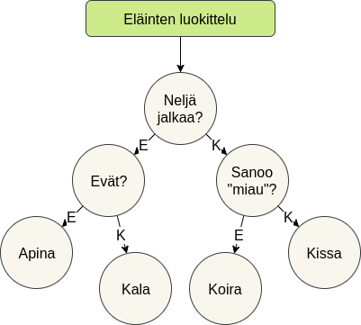

Mallin rakentuminen lähtee liikkeelle juurisolmusta (*root node*), jossa kaikkien havaintojen jaottelu aloitetaan. Mikäli jakoa ei tehtäisi, solmu sisältäisi sekaluokkia ja olisi näin huonolaatuinen. Kulloinkin jakoperusteeksi valittavalle piirteelle ja jakoarvolle on muutama yleistä karsintatapaa. Näitä ovat Gini-indeksiä eli Gini-epäpuhtautta (*impurity*) pienentävimmän, varianssia eniten vähentävän (*variance reduction*) ja informaatiota eli puhtautta (*purity*) lisäävimmän piirteen valinta. Puun annetaan kasvaa eli syventyä, kunnes jokin tyypillisistä ehdoista täyttyy: lehtisolmut (*leaf node*) ovat luokkiin nähden puhtaita, puun syvyys saavuttaa sille määritetyn rajan tai solmun jakamiseen ei ole määritettyä minimimäärää havaintoja.

Näin toimien meidän mallimme on ensin valinnut merkittävimmäksi jakamisperusteeksi jalkojen lukumäärän. Tämän jälkeen neljäjalkaiset on jaettu niiden ääntelyn perusteella, ja jäljelle jääneet evien olemassaolon mukaan. Ja päätöspuut ovat ytimessään esimerkin kaltaisia siinä, että niiden luokitteluperusteista on ihnimillisesti helppoa päästä perille.

Luokittelupuilla on kuitenkin ongelmiakin. Ne ensinnäkin ylisovittuvat helposti, sillä jokaiselle poikkeukselle rakennetaan polku, mikäli mallia ei erikseen säännöstellä (*regularize*). Koska solmut myös jakautuvat vain kahtia, kärsivät päätöspuut myös helposti käsiin räjähtävästä monimutkaisuudesta. Ne ovat alttiita datasetissä tapahtuville muutoksille ja ovat usein myös muita ohjattuja menetelmiä epätarkempia. Samoin mallit painottavat solmujen jakamisperusteissa niitä muuttujia, joilla on useampia arvoja. Koska jokainen solmun jako tapahtuu kunkin solmun ehdolla, malli voi olla lokaalisti optimi mutta globaalisti keskinkertainen

### Decision Forests

Hankalasti suomennettava sana *ensemble* tarkoittaa luokittelun yhteydessä montaa yksittäistä luokittelijaa koottuna yhdeksi laajemmaksi malliksi. Tavoitteena on yhden, yksittäistä mallia laadukkaamman mallin tuottaminen. Perinteisesti nämä mallit ovat joko yksittäisistä päätöspuista rakennettuja metsiä (monta rinnan) tai kaltevuuden tehostamiseen (*gradient boosting*) pohjaavia päätöspuita (monta peräkkäin).

Eräs metsä-ensemblen esimerkki on satunnaismetsä (*random forest*), jossa muodostetaan malli jopa kymmenistä tuhansista yksittäisistä päätöspuista. Jokainen satunnaismetsän puista koulutetaan ensin yksittäin, minkä jälkeen mallin ulostulo muodostetaan puiden ennusteista joko moodin (luokittelu) tai keskiarvon (regressio) avulla. Jotta puut ovat riittävän erilaisia, ne koulutetaan satunnaisesti muodostetulla datasetin osalla ja koulutuksen aikana myös käytettävien piirteiden määrää rajoitetaan. Kun jokainen puu koulutetaan näin, ei yksi tai monikaan ylisovittunut yksittäinen puu muodostu ongelmaksi - ne poikkeavat perustavanlaatuisesti toisistaan käytetyn datan ja piirteiden osalta.

Kaltevuus-tehostetut puut muodostetaan metsistä poiketen siten, että monta heikkoa mallia ketjutetaan valikoivasti yhdeksi isoksi malliksi käyttäen jyrkimmän kaltevuuden menetelmää. Heikolla mallilla tarkoitetaan syvyyden, solmujen määrän tai solmukohtaisten vähimmäisnäytteiden osalta rajoitettua yksittäistä päätöspuuta. Puita lisätään yksitellen, kunnes malli tuottaa kokonaisuudessaan halutun tasoisen tuloksen. [XGBoost](https://github.com/dmlc/xgboost) on yksi eniten mainetta niittäneistä näin toimivista malleista. Satunnaismetsiin verrattuna kaltevuus-tehostut puut ovat kuitenkin herkempiä ylisovittumaan.

### Support Vector Machines

Yksinkertaisimmillaan tukivektorikone (*support vector machine, SVM*) on lineaariluokittelija logistisen lineaarimallin tavoin. Suurimpana poikkeavuutena on tapa, jolla algoritmin kohdefunktio lasketaan. Vain niistä näytteistä menetetään pisteitä, jotka ovat luokiteltu väärin tai liian lähellä luokittelurajaa. Tämä tunnetaan saranahäviönä (*hinge loss*) ja sen tavoitteena on löytää havainnot riittävän selkeästi oikein erottava luokittelun päätösrajapinta (*decision boundary*).

Tarkemmin kyse on sellaisen päätösrajapinnan löytämisestä, joka maksimoi eri luokkien lähimpien näytteiden etäisyyden määrätyn kokoisella varovyöhykkeellä pinnan molemmin puolin - ts. marginaalin maksimoinnista. Tätä varten menetelmä asettaa datanäytteiden joukkoon tukivektoreita, jotka eivät kuitenkaan vaikuta kohdefunktion arvoon ja näin säätyy sovittumaan dataan. Se hyödyntää myös niin sanottua kernelitemppua (*kernel trick*), jossa epälineaarinen data saadaan kuitenkin erotettua lineaarisesti. Alla oleva kuva löytyy Wikipedian [*Kernel method*](https://en.wikipedia.org/wiki/Kernel_method)-artikkelista ja näyttää, miten epälineaarisesti jakautunut data (vas.) saadaan lineaarisesti erotettua (oik.) ilmaisemalla havainnot kolmannellakin ulottuvuudella. Se on laskettu etäisyytenä vasemman kuvan ympyrän keskipisteestä.

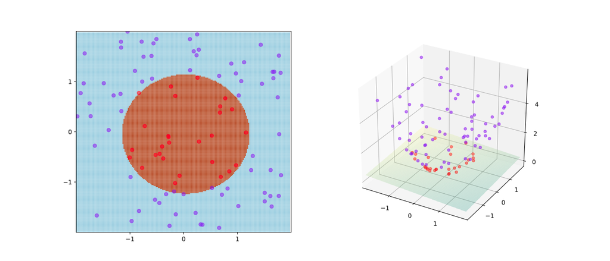

Menetelmä on toki tehokas monipiirteisten datasettien kanssa, mutta se ei skaalaudu suuriin havaintomääriin. Samoin menetelmän ulostuloja on käsiteltävä erikseen, jotta luokittelusta voitaisiin tuottaa regressiotuloksia.

### Naive Bayes

Naiivi Bayesin malli on yksi vanhimmista luokittimista ja saa liikanimensä siitä, että se olettaa naiivisti kunkin datasetin piirteen olevan sekä riippumaton että tilastollisesti jotenkin jakautunut - nämä oletukset eivät tosielämässä päde. Roskapostien luokitteluun vietynä tämä tarkoittaisi, että jokaista sähköpostin sanaa katsotaan vain irrallaan, muodostaen sanakohtaiset todennäköisyydet luokittelun tekemiseksi. Menetelmä hyödyntää Bayesin todennäköisyysteoreemia ehdollisten todennäköisyyksien laskennassa, josta taas nimen toinen osa juontaa. Yksinkertaistaen menetelmällä lasketaan ehdollisia todennäköisyyksiä sille, että jokin havainto kuuluu johonkin luokkaan - havainto on täten ehto ja luokkaan kuuluminen ennustettava todennäköisyys.

Tälle algoritmille ei tarvitse määrittää kohdefunktiota tai optimointialgoritmia, sillä menetelmä laskee todennäköisyydet aina suhteessa havaintojen määrään ja toimii [deterministisesti](https://en.wikipedia.org/wiki/Deterministic_algorithm) parametrien iteratiivisen optimoinnin sijasta. Tästä johtuen menetelmä on hyvin tehokas, joskin se on hyvin lähellä lineaarisuudessan logistista regressiota.

### k-Nearest Neighbors

Lähimpien naapurien (*nearest neighbors*) algoritmi on tyyppiesimerkki laiskasta ryhmittely- eli klusterointialgoritmista. Klusterointialgoritmeille ominaisesti menetelmä oppii käymällä läpi koko datasetin. Menetelmä on hyvin yksinkertainen.

Jokainen havainto käydään läpi yksitellen siten, että ne käsitellään pisteinä avaruudessa, jossa jokaista datan piirrettä käsitellään omana ulottuvuutenaan. Luokittelu tapahtuu ottamalla $k$ käsiteltävän havainnon lähintä toista havaintoa ja asettamalla näiden havaintojen keskimääräisesti tai moodillisesti suurin luokka myös havainnon luokaksi. Alla oleva kuva havainnollistaa tätä.

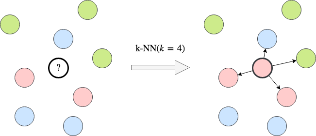

Yksinkertaisuudella on kuitenkin hintansa. Itse malli paisuu todella nopeasti, sillä jokainen havaintotieto talletetaan, jolloin mallin muistivaatimukset ovat aina vähintään datasetin tasoa. Samoin menetelmä on hidas, sillä havaintojen luokittelu tapahtuu verraten kutakin havaintoa kaikkiin muihin havaintoihin. Malli luokittelee herkästi myös suurinta luokkaa (eniten havaintoja) suosien. Tämän lisäksi menetelmä kärsii vakavasti [ulottuvuuksien kirouksesta](https://en.wikipedia.org/wiki/Curse_of_dimensionality), jolloin piirteiden määrän kasvu räjäyttää tarvittavien laskujen määrän jopa eksponentiaalisesti.

### Neural Networks

Keinotekoisilla neuroverkoilla (*artificial neural networks, ANNs*) tarkoitetaan koneoppimismenetelmien alaryhmää, jotka pohjaavat jo 1940-luvulla esitettyyn [McCullogh-Pittsin lineaarikynnysmalliin](http://aishack.in/tutorials/artificial-neurons-mccullochpitts-model/). Mallin perusideana oli pyrkiä matkimaan aivojen yhteyksie mallintamalla biologisia neuroneja ja synapseja solmuilla (*node*) ja painoilla (*weight*). Vaikka teoria on ollut olemassa jo vajaan vuosisadan, vasta tietokoneiden laskenta- ja tallennuskapasiteetin ja riittävän suurten datasettien kehittymisen myötä mallit alkoivat ohittaa käyttökelpoisuudessaan perinteisiä koneoppimismenetelmiä.

Neuroverkkojen toiminta rakentuu hyvin vahvasti Frank Rosenblattin [Perseptroniin](https://towardsdatascience.com/what-the-hell-is-perceptron-626217814f53), jonka perustana ovat seuraavat elementit:

- Syötteet (*inputs*), eli yhden havainnon piirteet kukin omana arvonaan.
- Painot (*weights*), eli kertoimet, joilla syötteitä painotetaan.
- Neuroni, joka laskee yhteen painotetut syötteiden arvot.
- Aktivointifunktio (*activation function*), joka skaalaa neuronin summan välille `0 ... 1`.
- Ulostulo (*output*), eli skaalattu neuronin arvo.

Tyypillisesti neuroni ja aktivointifunktio käsitellään kuitenkin yhtenä kiinteänä yksikkönä. Allaoleva kuva selventää perseptronin rakennetta. Käytännössä perseptroni on lineaariluokitin, joka oppii kunkin kertoimena käytettävät syötekohtaiset painot ja tuottaa ulostulona todennäköisyyden. Tässä mielessä käytännön toiminnallisuus vastaa hyvin paljon lineaarista luokitinta.

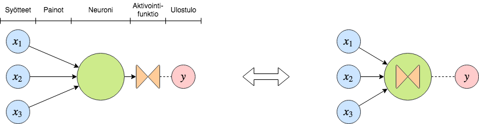

Yhdestä perseptronista päästään neuroverkkoihin lisäämällä sekä rinnakkaisten että peräkkäisten neuronien määrää. Perinteinen myötäkytketty verkko (*feedforward network*) tunnetaankin myös nimellä monikerrosperseptroni (*multi-layer Perceptron, MLP*). Luokitteluun sopiva yhden piiloneuronikerroksen (*hidden layer*) sisältävä myötäkytketty verkko voisi näyttää esimerkiksi alla olevan kuvan mukaiselta. Viimeinen neuroni ennen ulostuloa $y$ pitää huolen siitä, että verkko tuottaa ulostulona luokkaa ilmaisevan todennäköisyyden välillä `0 ... 1`. Yksisuuntaista kierrosta syötteistä $x$ aina ulostuloon asti kutsutaan etenemisläpäisyksi (*forward pass*). Mikäli kerroksia olisi useita, voitaisiin alkaa puhua jo syvästä neuroverkosta (*deep neural network*), joskaan tarkkaan rajattua kerrosten määrää verkon syväksi kutsumiseen ei ole.

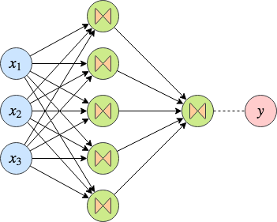

Neuroverkkojen koulutukseen eli painojen optimointiin löytyy laaja kirjo erilaisia optimointialgoritmeja. Perinteisesti paljon käytetty ja suoraviivainen on stokastinen jyrkimmän kaltevuuden menetelmä (*stochastic gradient descent, SGD*) edellisten iteraatioiden painokohtaisia arvoja huomioivan momentin (*momentum*) kanssa. Kuten muillakin menetelmillä, optimointi tapahtuu suhteessa valitun kohdefunktion laskemaan verkon ulostulon ja oikean vastauksen väliseen virheeseen, toisin sanoen etenemisläpäisyn jälkeen. Itse optimointi tapahtuu etenemisläpäisyyn nähden käänteisesti, kullekin mallin painolle lasketaan niiden osuus virheestä osaderiivaattoina eli gradientteina alkaen ulostuloa lähimmistä painoista ja edeten kerros kerrallaan syötteisiin asti. Tätä kutsutaan paluuläpäisyksi (*backward pass*).

Neuroverkot kärsivät kuitenkin kahdesta merkittävästä ongelmasta. Itse mallit ovat ensinnäkin hyvin hankalia ymmärtää. Niiden kyky tarjota ihmiselle ymmärrettäviä selityksiä kullekin ulostulolle on myös hyvin vaikea tavoittaa. Nämä ovatkin edelleen tutkimuksen kohteita. Vaikkakin nämä mallit ovat todella tehokkaita, on suositeltavaa suosia perinteisiä koneoppimismenetelmiä niiden riittäessä.

### Practical Considerations in Classification

Teoriassa koneoppimisessa on yksinkertaisuudessaan kyse datan syöttämisestä mallia kuvaavan mallimatriisin (*design matrix*) läpi luokittelutuloksen tuottamiseksi. Käytännössä toimivan mallin ohjelmointi vaatii monien valintojen tekemistä, ennenkuin käsillä on luotettavasti toimiva luokittelumalli.

#### Selecting a Model Family

Ensimmäinen päätöksistä on luokittelualgoritmin valinta. Jo esiteltyjen algoritmien lisäksi löytyy vielä monia muitakin malleja ja tärkeintä onkin valita tehtävään soveltuvin menetelmä. Paras tapa selvittää soveltuvin menetelmä on kokeilla eri vaihtoehtoja tehtävään tarkoitetulla datalla. Mikäli tähän ei ole jostain syystä mahdollista, seuraavien tekijöiden punnitseminen yhdessä voi auttaa:

- **Laskenta:** Mallin kouluttaminen riittävän nopeasti on yksi mallintamisen tavoitteista. Se auttaa myös virheiden korjauksessa implementaation osalta. Nopeasti koulutettavia malleja ovat mm. logistinen regressio, tukivektorikoneet ja päätöspuut. Kernel-pohjaiset tukivektorikoneet ja neuroverkot vaativat koulutuksen osalta enemmän aikaa.
- **Matematiikka:** Joskus lineaarimallit toimivat käsillä olevan datan kanssa hyvin, sillä data on luontaisesti lineaarisesti erottuvaa. Näin ei kuitenkaan aina ole, sillä datassa on usein monia epälineaarisuuksia ja tällöin lineaarimallit eivät toimi. Näissä tilanteissa päätöspuut, kernel-tukivektorikoneet ja neuroverkot toimivat.
- **Selittyvyys:** Joissain tapauksissa mallin tekemille päätöksille on kyettävä antamaan perustelut, kuten esimerkiksi väärin tapahtuneen luokittelun seurauksen oikeat oikeudet omaavan henkilön palveluun pääsyn epäämisessä. Päätöspuut ovat ehdottomasti parhaita tässä tapauksesa. Logistisen regression ja naiivin Bayesin mallien lineaaripainoja voidaan myös käyttää jonkinlaisen selityksen tuottamiseen. Päätöspuumetsät, tukivektorikoneet ja neuroverkot ovat eritäin hankalia tulkittavia.

Päätöspuita suositellaan käytettäväksi, kun piirteitä on maksimissaan joitakin tuhansia ja logistista regressiota kymmenien tuhansien piirteiden kanssa.

#### Training Data Construction

Ohjatun oppimisen ongelmassa käytetään dataa, jossa havainnot on jollain tapaa valmiiksi luokiteltuja. Mallintamisen tavoitteena on aina käyttää historiallista dataa tulevaisuuden havaintojen luokittelemiseksi. Tällöin osa koulutukseen varatusta datasta on erotettava testidataksi, jota malli ei koulutuksen yhteydessä ole vielä nähnyt. Tapoja tämän toteuttamiseen ovat mm. seuraavat:

- **Ristiinvalidointi** (*cross-validation*): Tämä on standardimenetelmä, jossa koulutusdata jaetaan osiin sekoittaen. Tämän jälkeen osia käytetään koulutukseen siten, että kukin osista toimii kerran validointidatana ja loput osat koulutusdatana. Näin koulutus tapahtuu kirjaimellisesti validoimalla malli ristiin koko koulutusdatan kanssa. Ristiinvalidoinnin jälkeen jokaisesta koulutusdatajaottelulla koulutetusta mallista ja tuotetusta virheestä lasketaan keskiarvo ja tämä on yhden koulutusiteraation lopullinen tulos.
- **Kouluta-validoi-testaa** (*train-validate-test*): Ristiinvalidointiin verrattuna tässä menetelmässä data jaetaan vain kolmeen osaan: koulutus-, validointi- ja testidataan. Kahdella ensimmäisellä malli koulutetaan ja sen esimerkiksi viritetään sen parametrien osalta (*hyperparameter tuning*) ja viimeisellä testataan mallin lopullista suorituskykyä sille tuntemattomien havaintojen kanssa.
- **Ajan huomioiva validointi** (*out-of-time validation*): Mikäli datan jakauma muuttuu ajan kuluessa ja tavoitteena on kyetä mallintamaan tulevaa, on näytteet järkevä jakaa koulutus-, validointi- ja testisetteihin vanhimmista näytteistä uusiimpiin. Jakotapa vastaa kouluta-validoi-testaa-tapaa.

Alla on vielä kuvan muodossa esitetty koulutusdatojen jakotavat ja käyttö mallin kanssa.

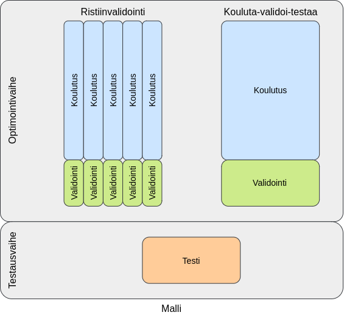

#### Unbalanced Data

Harvinaisten asioiden luokittelussa datasetti on usein vahvasti epätasapainossa. Tällöin on tärkeä ymmärtää, että aihe on ensinnäkin jossain määrin kiistanalainen sen suhteen, mitä mallin tahdotaan oppivan. Näissä tilanteissa voidaan kuitenkin toimia seuraavilla tavoilla:

- **Ylinäytteistys** (*oversample*): Pienempää luokkaa nostetaan koulutuksen aikana esiin useammin, jotta mallin luokkakohtaiset havaintomäärät tasaantuisivat.
- **Alinäytteistys** (*undersample*): Suurempaa luokkaa nostetaan harvemmin, syy sama kuin ylinäytteistyksellä.
- **Kohdefunktion säätö**: Kohdefunktiota voidaan säätää painottamaan pienemmän luokan tulosten merkityksellisyyttä enemmän, kuin suuren luokan tuloksia.

Esimerkki epätasaisesta luokka- tai havaintojakaumasta on palvelunestohyökkäykset, jossa yksinkertaisemmat määrään ja voimaan perustuvat hyökkäykset (*brute force*) kattavat huomattavan osan datasetistä suhteessa pienimuotoisempiin mutta huomattavasti hienovaraisemmin suunniteltuihin hyökkäyksiin.

#### Missing Features

Joskus myös on niin, että osasta dataa puuttuvat jotkin piirteet. Se voi olla seurausta datan keruuprosessin iteratiivisesta kehittymisestä tai yksinkertaisesti keruuvaikeuksista. Näissä tapauksissa on kyettävä tekemään kokonaisuutta parhaiten palveleva päätös. Mikäli dataa on riittävästi, voidaan puutteelliset näytteet jättää kokonaan pois, mikäli datan jakauma ei tämän seurauksena vääristy merkittästi. Toinen lähestymistapa on puuttuvien havaintojen korvaaminen (*imputation*) käyttäen datasetin havaintojen tilastollisia tunnuslukuja - keskiarvoa, mediaania tms. Korvaamista varten on jopa mahdollista kehittää oma puuttuvia arvoja ennustava mallinsa.

#### Attacker Evolution

Tietoturvallisuudessa on kyse jatkuvasti muuttuvasta tilanteesta, jossa sekä puolustaja että hyökkääjä pyrkivät mukautumaan toistensa toimintatapaan ja nousemaan toista korkeammalle tiedollisesti ja taidollisesti. Uusimpien tilanteiden mallintaminen voi korostua merkittävyydessään, jolloin historiassa kauempana olevat tilanteet jäävät vähemmälle huomiolle. Mikäli puolustaja pyrkii hyödyntämään automatiikkaa koneoppimisen ja mallinnuksen keinoin, on historiatietojen huomiointi ja mukanakuljetus nykyhetken tilanteiden rinnalla tärkeää, sillä muutoin vanhat tietoturva-aukot jäävät huomiotta ja muuttuvat uhiksi.

### Feature Selection

Laskennallisen kapasiteetin ollessa kunnossa, menee suurin aika koneoppimismallin datasetin piirteiden - merkityksellisien signaalien, muuttujien ja tapahtumien luvullisen ilmaisun - rakentamiseen. Hyvin valitut piirteet auttavat mallia tavoittaamaan datasta mallinnuksen kannalta olennaisen, kun taas huonosti valittuina piirteet voivat jopa rampauttaa tehokkaankin mallin. Tärkeää on piirteiden keskinäisten riippuvuuksien tilastollinen vertailu riittävän riippumattomien piirteiden löytämiseksi.

Piirteiden valitsemiseksi on monia keinoja. Jotkin algoritmit, kuten päätöspuut, logistiset regressiomallit ja tukivektorikoneet tarjoavat koulutettuina tietoa merkittävimmistä piirteistä. Säännöstelyllä (*regularization*) voidaan myös auttaa mallia sovittumaan suhteessa itsenäisimpiin piirteisiin. Samoin riittävän pienten piirremäärien kanssa voidaan edetä käsipelillä ottaen ja pudottaen piirteitä pois ja tarkastellen lopputulosta.

### Overfitting and Underfitting

Yli- tai alisovittumisella tarkoitetaan mallin dataan sovittumisen kahta ääripäätä. Ylisovittuessaan malli oppii koulutusdatan lähes täydellisesti, milloin se kykenee luokittelemaan kunkin koulutusdatasetin näytteen lähes täydellisesti. Näin sovittunut malli ei kuitenkaan ole käyttökelpoinen, sillä se ei useinkaan kykene luokittelemaan sellaisia havaintoja luotettavasti, joita se ei ole koulutusvaiheessa havainnut. Alisovittuminen on ääripäistä toinen ja silloin malli ei kykene kunnolla löytämään datan ominaisia piirteitä.

Usein sovittumisen asteen määrittävänä tekijänä on mallin monimutkaisuus (*complexity*). Mitä yksinkertaisempi malli, sitä rajoitetumpaa sen sovittuminen on. Mitä monimutkaisempi malli, sitä paremmin se pystyy sovittumaan koulutusdataan. Monimutkaiset mallit kykenevät tuottamaan hyviä koulutustuloksia eli sovittumaan hyvinkin tarkasti niille syötettyyn dataan. Yleistymisen (*generalization*) näkökulmasta tämä on kuitenkin ongelmallista edellä mainituista syistä, sillä koulutus- ja testivirheet jäävät todella kauas tosistaan. Tämä ero tunnetaan yleistymisvirheenä (*generalization error*) tai -kuiluna (*- gap*).

Yksi tavoista pienentää mallien yleistymisvirhettä on jo tähänkin mennessä muutamaan otteeseen esiintynyt säännöstely (*regularization*). Tällä tarkoitetaan mallin monimutkaisuuden rajoittamista lisäämällä virhefunktioon säännöstelyparametri (*regularzation parameter*) itse malliin koskematta. Tässä vaiheessa ei voida enää puhua virhefunktiosta, vaan kyse on kohdefunktiosta. Tämän parametrin valinta omine säätöineen on kuitenkin yrityksen ja erehdyksen kautta tapahtuva prosessi.

### Choosing Thresholds and Comparing Models

Tietoturvan luokittelutehtävissä on usein harmaita vyöhykkeitä, jossa epävarma luokittelutilanne voi vaatia lisätoimenpiteiden teettämistä esimerkiksi järjestelmään pyrkivälle toimijalle. Tällöin on kyse oikeiden raja-arvojen (*threshold*) määrittämisestä. Käytännössä tässä on kyse liiketoiminnan osa-alueiden tasapainosta - kuinka paljon painottaa tietoturvaa ohi käyttäjäkokemuksen. Tällöin voidaan esimerkiksi sallia mallille yksi turvalliseksi luokiteltu todellinen uhka kymmentä uhaksi luokiteltua turvallista tapahtumaa kohden.

Tässä kohden myös astuu kuvaan mallien vertailu. Eri tavoin koulutetut ja eri menetelmiin perustuvat mallit on hyvä arvioida suhteessa määritettyyn kohdefunktioon tai luokittelutarkkuuteen. Muita keinoja ovat esimerkiksi [ROC-kurvin](https://en.wikipedia.org/wiki/Receiver_operating_characteristic), jota näytteiden nostotapa (*sampling*) ei juuri vääristä.

## Clustering

Asiat tapahtuvat usein ryppäissä, kuten mm. murtautumisyritykset järjestelmiin ja roskapostien lähetys. Tällöin ollaan tekemisissä samankaltaisten tapahtumien tai havaintojen ryhmittelyn (*clustering*) kanssa. Tässä osiossa käydään läpi ryhmittelymenetelmiä ja sitä, miten saada tietoa kustakin menetelmän tuottamasta ryhmästä tarvittavien toimenpiteiden tekemiseksi - toisin sanoen ryhmien luokittelusta.

### Clustering Algorithms

Klusteroinnin perustana oleva intuitio on ryhmitellä jollain tavalla läheiset havainnot yhteen. Algoritmista riippuen käytetään eri etäisyysmittaa (*metric*), mutta perusajatus on sama.

#### Grouping

SQL-syntaksia vastaava ryhmittely (*grouping*) eli `GROUP BY` on kaikista yksinkertaisin tapa ryhmitellä tapaa. Siinä rividata ryhmitellään jonkun piirteen mukaan siten, että kyseisen piirteen osalta saman arvon omaavat rivit ryhmitellään samaan ryhmään. Esimerkiksi yhdestä ja samasta IP-osoitteesta tulevat pyynnöt on helppo ryhmitellä yhteen.

#### k-Means

Varsinaisista ryhmittelyalgoritmeista iteratiivinen $k$-keskiarvon (*mean*) menetelmä on yksi tyypillisimmistä. Menetelmä perustuu siihen, että datan joukkoon sirotellaan satunnaisesti $k$ kappaleitta keskuspisteitä (*centroid*), joihin varsinaisten havaintojen etäisyyksiä mitataan. Kun ensimmäiset etäisyydet on laskettu, asetetaan kunkin havainnon luokaksi sitä lähin keskuspiste. Tämän jälkeen kullekin näin muodostetulle ryhmälle lasketaan niiden arvojen mukainen todellinen keskuspiste keskiarvona ja havainnot ryhmitellään uudelleen suhteessa muuttuneisiin keskuspisteisiin. Kun mikään havainto ei enää vaihda luokkaansa on algoritmi valmis.

Alla olevassa kuvassa näytetään menetelmän toiminta.

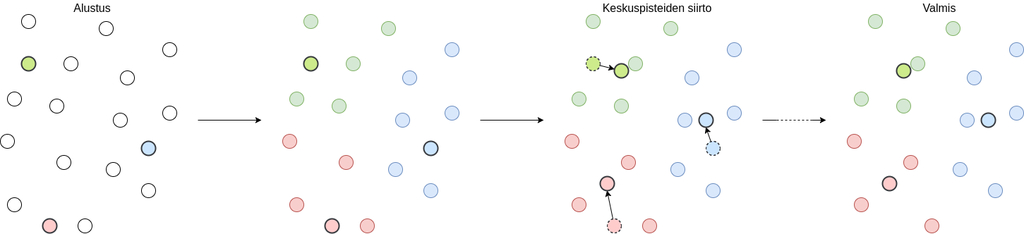

Optimaalinen $k$ on etsittävä manuaalisesti. Hyvä tapa tähän on käyttää kyynärpäämenetelmää (*elbow method*). Tällöin lähdetään jostain $k$-arvosta eteenpäin ja ryhmitellään data. Tämän jälkeen arvoa kasvatetaan yhdellä ja ryhmitellään jälleen. Jokaisesta ryhmittelystä lastetaan keskimääräinen etäisyys keskuspisteisiin. Mitä enemmän keskuspisteitä, sitä hitaammin etäisyyksien keskiarvo alkaa laskemaan. Tyypillisesti jonkin $k$-arvon kohdalle syntyy kyynärpäätä muistuttava kohta, jossa nopeasti pienenevä keskiarvo alkaa pienenemään hitaammin. Tätä arvoa on tavallista käyttää optimaalisena, ellei jotain ennakkotietoa halutusta luokkien määrästä ole.

Menetelmällä on jotain rajoitteita. Se vaatii datalta normalisointia. Se myöskään toimi kategoristen tai binääristen muuttujien kanssa kovin hyvin tai ollenkaan. Myös piirteiden määrän kasvu rampauttaa menetelmän.

#### Hierarchical Clustering

Hierarkinen ryhmittely eroaa $k$-menetelmistä siinä, että ryhmien määrä valitaan tai voidaan valita menetelmän kouluttamisen jälkeen. Menetelmä perustuu siihen, että havainnoista rakennetaan binääripuu joko alhaalta ylös tai ylhäältä alas.

Alhaalta ylös rakentaminen tapahtuu siten, että läheisimmät havainnot niputetaan yhdeksi solmuksi ja nämä solmut jälleen uusiksi solmuiksi. Kun uusia solmuja ei voida enää muodostaa eli puun juuri on saavutettu, menetelmä on valmis. Tätä kutsutaan kokoavaksi (*agglomerative*) hierarkiseksi ryhmittelyksi. Ylhäältä alas edetään päinvastaisti jakaen solmuja, kunnes uloimmissa solmuissa on kussakin vain yksi havainto. Tämä tunnetaan jakavana (*divisive*) hierarkisena ryhmittelynä.

Tämä menetelmä muodostaa puukuvaajan (*dendrogram*), joka on kuvattu alla. Vetämällä lävistäjiä kunkin tason läpi voidaan muodostaa haluttu määrä ryhmiä lävistäjän läpi kulkevien oksien määrän mukaan. Kun $k$ halutaan vaikkapa kahdeksi, on toisessa ryhmässä viisi havaintoa ja toisessa yksi.

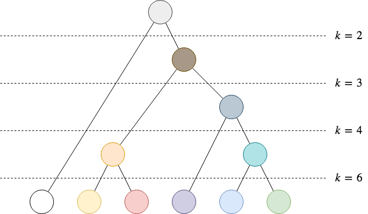

Kuten puumalleilla yleensä, puukuvaajasta on helppoa päästä käsiksi datan jakautuneisuuteen. Edellä esiteltyyn $k$-keskiarvomenetelmään nähden hierarkinen klusterointi toimii monenlaisilla etäisyysmitoilla ja datatyypeillä, kategorinen data mukaanluettuna. Sen käyttö on kuitenkin epämielekästä suurten datasettien kanssa laskennallisten ja tallennuksellisten vaatimusten kasvun vuoksi.

#### Locality Sensitive Hashing

Etäisyysmenetelmät toimivat hyvin datalla, jossa piirteiden määrä on rajattu. Esimerkiksi tekstidokumentit ovat tällaisille menetelmille kuitenkin mahdottomia ryhmiteltäviä jo yksistään mahdollisten sanojen määrän ja niiden eri järjestysten miltei rajattoman määrän vuoksi. Kun kyseessä on tällaiset moni-muuttujaiset havainnot, on yksi kelvollinen samankaltaisuuden mitta Jaccardin samankaltaisuus (*Jaccard similarity*). Siinä samankaltaisuutta mitataan kahden havainnon välillä samojen piirteiden ja eroavien piirteiden suhteella. Ne havainnot, joiden samankaltaisuus on korkea, ovat luonnollisesti ryhmiteltävissä samaan ryhmään.

Ongelmaksi muodostuu kuitenkin se, että jokaisen havainnon vertaaminen jokaiseen toiseen havaintoon on äärimmäisen tehotonta. Tämä ongelma on pyritty ratkaisemaan jo ensimmäisen luvun esimerkissäkin käytetyllä havainnoista muodostettujen tiivisteiden samankaltaisuuden huomioivalla (*locality-sensitive hashing, LSH*) mallilla.

Menetelmän käyttö alkaa monimuuttujaisen datan jakamisella setiksi. Esimerkiksi tekstidokumentit on tapana jakaa muutaman sanan limittäisiin lastuihin (*shingle*). Tällöin lause "Yksi, kaksi, kolme ja neljä" muuntuisi kolmen sanan lastujen setiksi seuraavasti:

```
{(yksi, kaksi, kolme), (kaksi, kolme, ja), (kolme, ja, neljä)}
```

Lastujen käyttö kahden havainnon Jaccardin samankaltaisuuden määrittämiseen on jo sinänsä mahdollista toteuttaa, joskin se on raskasta kunkin lastun muodostaessa edelleen monielementtisen listan. Tämän vuoksi jokainen lastu syötetään tiivistefunktioon (*hash function*), joka tuottaa samankaltaisella datalla aina samankaltaisen tuloksen. Tällöin lista saadaan muunnettua esimerkiksi luku- tai merkkijonoksi. Näiden tiivisteiden vertaaminen on paljon nopeampaa listojen vertaamiseen verrattuna. Tämän kaltainen lähestymistapa tunnetaan MinHash-algoritmina.

#### k-Dimensional Trees

Luokittelun yhteydessä esitetty $k$-naapurin toimii pohjimmiltaan $k$-ulotteisen päätöspuun (*$k$-dimensional decision tree*) pohjalta. Kuten päätöspuissa yleensä, myös $k$-ulotteisessa puussa dataa jaetaan valikoidusti aina yhden piirteen mukaisesti aina siihen asti, kunnes puun lehdissä on säädetty määrä näytteitä. Näin mallinnetaan koko datan piirteiden aliavaruus, jossa data on jossain määrin mielekkäästi jaoteltu eri ryhmiin puukuvaajan tavoin. Ne kärsivät myös samoista ongelmista, kuin muut puumallit.

#### DBSCAN

Kohinaisten havaintojen tiheä ryhmittely (*density-based spatial clustering of applications with noise, DBSCAN*) on suorituskykyinen ja suosittu menetelmä, joka etäisyyksien sijasta jakaa havainnot tiheiksi ryhmittymiksi. Ryhmien määrää ei aseteta, vaan menetelmä määrittää sen itse. Jokainen havainnoista luokitellaan aina ryhmän ydin-, raja- tai kohinapisteeksi sen mukaan, mikä on menetelmälle määritelty ryhmän "halkaisija". Ryhmät muodostetaan ydinpisteiden ympärille.

Menetelmän käytön vaatimuksena kuitenkin on, että data on riittävän selkeästi jakautunutta. Samoin menetelmän käyttö vaatii sen hyperparametrien huolellista säätöä. Se ei myöskään taatusti tuota aina samankaltaista lopputulosta, vaikka hyperparametrit ja data olisivatkin samat kautta linjan. Korkeapiirteisen datan kanssa kohdataan myös ongelmia.

### Evaluating Clustering Results

Koska ryhmittelyssä ei edetä ohjatusti luokkia oppimalla, on menetelmien suorituskykyä mitattava niille soveltuvin keunoin. Kaksi tyypillistä ryhmittelyn suorituskykymittaria ovat yhdenmukaisuus (*homogeneity*) ja täydellisyys (*completeness*). Mitä enemmän ryhmissä on vain tiettyä luokkaa, sitä yhdenmukaisempia ne ovat. Mitä vähemmän luokat ovat hajonneet eri ryhmiin, sitä täydellisempiä ryhmät ovat. Näiden kahden yhdistelmätunnusluku, harmoninen keskiarvo (*harmonic mean*), tunnetaan V-mittana. Tämän mitan, kuten yhdenmukaisuuden ja täydellisyyden mittojenkin kohdalla, vaatimuksena on luokkien tietäminen ennalta.

Muita tunnettuja mittoja ovat:

- **Siluettikerroin** (*silhouette coefficient*): Menetelmässä lasketaan kullekin havainnolle siluettikerroin siten, että havainnon keskietäisyyttä sen ryhmän ja viereisen ryhmän havaintoihin verrataan keskenään. Mikäli etäisyys omaan ryhmään on merkittävästi suurempi verrattuna viereisen ryhmän havaintoihin, saa siluettikerroin kyseiselle havainnolle jopa negatiivisen arvon.
- **Calinski-Harabaz-indeksi**: Ryhmille laskettu indeksi on suurempi eli parempi, mitä tiheämpiä ja selkeämmin eroteltuja muodostetut ryhmät ovat. Tämä vastaa hyvin pitkälti tapaa, jolla ihmisetki luontaisesti määrittävät ryhmittelyn onnistumisen.

Joka tapauksessa ryhmittelyn tulosten arviointi on aina tapauskohtaista, sillä oikeiden luokittelutietojen puuttuessa on ryhmittelytulosta tarkasteltava suhteessa käytettävään dataan.